# An introduction to pavo 1.0

Rafael Maia, Pierre-Paul Bitton, Chad Eliason, Thomas White

2016-12-01

# Introduction

We are happy to introduce the stable release of `pavo 1.0`, which — among other things — includes a suite of new analysis and visualisation tools to make working with color data simpler and more intuitive than ever.

While we have made improvements that will expedite data organisation, the most significant developments in `1.0` relate to the analysis and visualisation of color data. This includes greater flexibility in the initial visual modelling process, and a host of new colorspace models and associated plotting options which are accessable through a simplified workflow. Below we will provide an overview of the main new features introduced in `1.0` in an example workflow.

# A Quick Guide For Familiar Users

We detail the changes and additions to the package below, but frequent users should be aware of the following main changes:

# New `flowers` Dataset

`data(flowers)` is a new example dataset consisting of reflectance spectra from 36 Australian angiosperm species. which we’ll use to illustrate many of the new features in this document.

```r
data(flowers)

flowercols <- spec2rgb(flowers)

head(flowers[1:4])
```

```
##    wl Goodenia_heterophylla Goodenia_geniculata Goodenia_gracilis
## 1 300             1.7426387            1.918962         0.3638354
## 2 301             1.5724849            1.872966         0.3501921
## 3 302             1.4099808            1.828019         0.3366520
## 4 303             1.2547709            1.784152         0.3231911
## 5 304             1.1064997            1.741398         0.3097854
## 6 305             0.9648117            1.699792         0.2964107
```

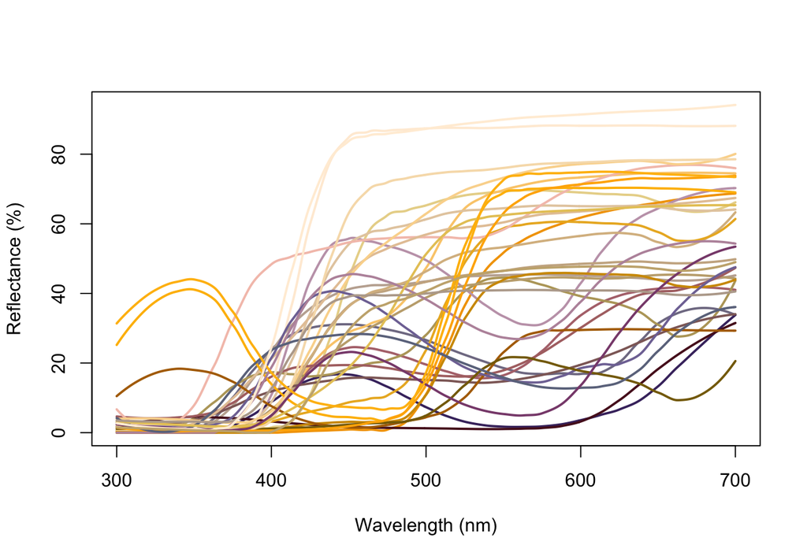

*The flower dataset*

```r
plot(flowers, lwd = 2, col = flowercols)
```

# Visual Modelling

## Visual Phenotypes

**`pavo 1.0` introduced several new di-, tri- and tetrachromatic visual systems, to accompany the suite of new models. The full complement of included systems are accessable via the `vismodel()` argument `visual`:**

`avg.uv` average ultraviolet-sensitive avian (tetrachromat)

`avg.v` average violet-sensitive avian (tetrachromat)

`bluetit` The blue tit *Cyanistes caeruleus* (tetrachromat)

`star` The starling *Sturnus vulgaris* (tetrachromat)

`pfowl` The peafowl *Pavo cristatus* (tetrachromat)

`apis` The honeybee *Apis mellifera* (trichromat)

`canis` The canid *Canis familiaris* (dichromat)

`musca` The housefly *Musca domestica* (tetrachromat)

`cie2` 2-degree color matching functions for CIE models of human color vision (trichromat)

`cie10` 10-degree color matching functions for CIE models of human color vision (trichromat)

As in previous versions, the individual sensitivity functions can be accessed via a call to `vissyst`, and visualised using `plot`. For example:

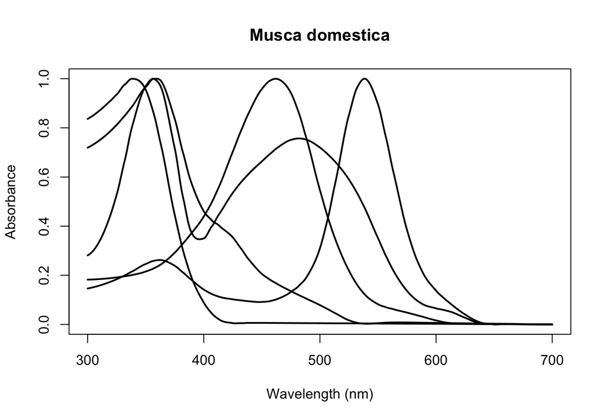

*The visual sensitivities of the muscoid fly Musca domestica.*

```r
plot(vissyst[, c('wl', grep('musca|md', names(vissyst), value = TRUE))], main = 'Musca domestica', ylab = 'Absorbance', lwd = 2)
```

## The `vismodel` Function and Receptor-Noise Limited Model

**Incorporating transmission into visual models.** The `vismodel` function is the first point of contact for visual modelling, as it estimates raw or relative photoreceptor stimulation. In `1.0`, we’ve introduced a new argument, `trans`, which allows for the explicit modelling of the effects of light transmission (e.g. through noisy environments or ocular filters). The argument defaults to `ideal` (i.e. no effect), though we can also use the built-in options of `bluetit` or `blackbird` to model the ocular transmission of blue tits/blackbirds, or specify a user-defined vector containing transmission spectra.

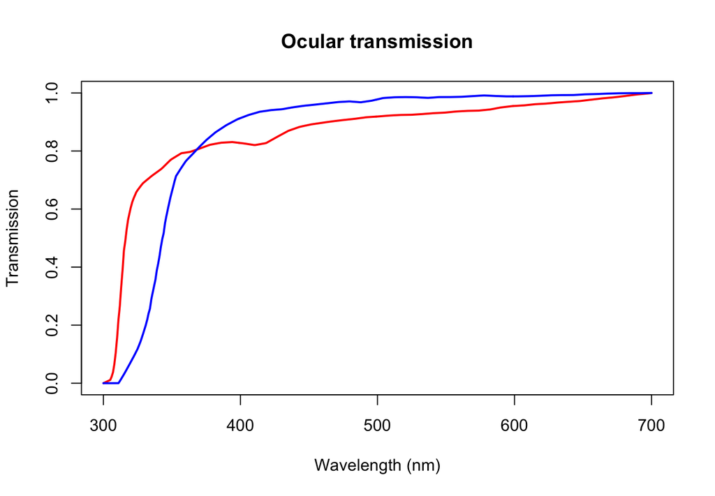

*Transmission example: Ocular transmission for the blue tit (red) and blackbird (blue) retinas.*

```r
plot(transmissiondata, lwd = 2, ylab = 'Transmission', main = 'Ocular transmission', col = c('red', 'blue'))
```

**Hyperbolic transformation of quantum catches.** Some of the default options for existing arguments have been expanded, such as the `visual` and `achromatic` arguments as outlined above. A significant new inclusion is the `qcatch = 'Ei'` option, which specifies the hyperbolic transformation of quantum catches according to:

$$E_i = \frac{Q_i}{Q_i + 1}$$

Where E<sub>i</sub> is the ’excitation value` for photoreceptor *i*, and Q<sub>i</sub> is the raw quantum catch of said photoreceptor. The transformation is a simplification of the Michaelis–Menton photoreceptor equation (Backhaus and Menzel 1987; Dowling 1987), and is particularly common in models of Hymenopteran vision we’ll see below (Backhaus and Menzel 1987; Backhaus 1991; Chittka 1992).

## Modelling and Plotting colorspaces

### The New `colspace` and `plot` Functions

The most significant structural changes in `1.0` involve the workflow for visual modelling, particular as regards the use of colorspaces. Previously, for example, we might use `vismodel` to model photoreceptor stimulation to an avian viewer, `tcs` to convert the data to points in a tetrahedral colorspace, and `tcsplot` to visualise the data. In `1.0` these, and all other, colorspace modelling and plotting options are now wrapped into the new `colspace` and `plot` functions. For modelling in colorspace, a typical workflow might use:

1. `vismodel` to estimate photoreceptor quantum catches. The assumptions of many colorspace models may differ dramatically, so be sure to select options that are appropriate for your intended use.
2. `colspace` to convert the results of `vismodel` (or user-provided quantum catches) into points in a given colorspace, specified with the `space` argument. If no `space` argument is provided, `colspace` will automatically select the di-, tri- or tetrahedral colorspace, depending on the nature of the input data. The result of `colspace` will be an object of class `colspace` (that inherits from `data.frame`; see the ‘Under-the-hood’ section below), and will contain the location of stimuli in the selected space along with any associated color variables.
3. `plot` the output. `plot` will automatically select the appropriate visualisation based on the input `colspace` object, and will also accept various graphical parameters depending on the colorspace (see `?plot.colspace` and links therein for details) .

examples are featured in detail below.

### New Di-, Tri-, and Tetrachromatic Spaces

`pavo 1.0`’s new workflow expands modeling and visualization capabilities of di- and trichromatic spaces, uniting these approaches in a cohesive workflow. As with most colorspace models, we first estimate relative quantum catches with various assumptions by using the `vismodel` function, before converting each set of values to a location in colorspace by using the `space` argument in `colspace` (the function can also be set to try to detect the dimensionality of the colorspace automatically). For di- tri- and tetrechromatic spaces, `colspace` calculates the coordinates of stimuli as:

**Dichromats:**
$$x = \frac{1}{\sqrt{2}}(Q_l - Q_s)$$

**Trichromats:**
$$x = \frac{1}{\sqrt{2}}(Q_l - Q_m)$$
$$y = \frac{\sqrt{2}}{\sqrt{3}}(Q_s - \frac{Q_l + Q_m}{2})$$

**Tetrachromats:**
$$x = \frac{1}{\sqrt{2}}(Q_l - Q_m)$$
$$y = \frac{\sqrt{2}}{\sqrt{3}}(Q_s - \frac{Q_l + Q_m}{2})$$
$$z = \frac{\sqrt{3}}{2}(Q_u - \frac{Q_l + Q_m + Q_s}{3})$$

Where Q<sub>u</sub>, Q<sub>s</sub>, Q<sub>m</sub>, and Q<sub>l</sub> refer to quantum catch estimates for UV-, short, medium-, and long-wavelength photoreceptors, respectively.

For a dichromatic example, we can model our floral reflectance data using the visual system of the domestic dog *Canis familiaris*, which has two cones with maximal sensitivity near 440 and 560 nm.

```r
vis.flowers <- vismodel(flowers, visual = 'canis')

di.flowers <- colspace(vis.flowers, space = 'di')

head(di.flowers)
```

```
##                                s         l           x      r.vec
## Goodenia_heterophylla 0.52954393 0.4704561 -0.04178143 0.04178143
## Goodenia_geniculata   0.25430150 0.7456985  0.34747015 0.34747015
## Goodenia_gracilis     0.01747832 0.9825217  0.68238870 0.68238870
## Xyris_operculata      0.39433933 0.6056607  0.14942675 0.14942675
## Eucalyptus_sp         0.40628552 0.5937145  0.13253229 0.13253229
## Faradaya_splendida    0.23166580 0.7683342  0.37948187 0.37948187
```

The output contains values for the relative stimulation of shot- and long-wavelength sensitive photoreceptors associated with each flower, along with its single coordinate in dichromatic space and its r.vector (distance from the origin). To visualise where these points lie, we can simply plot them on a segment.

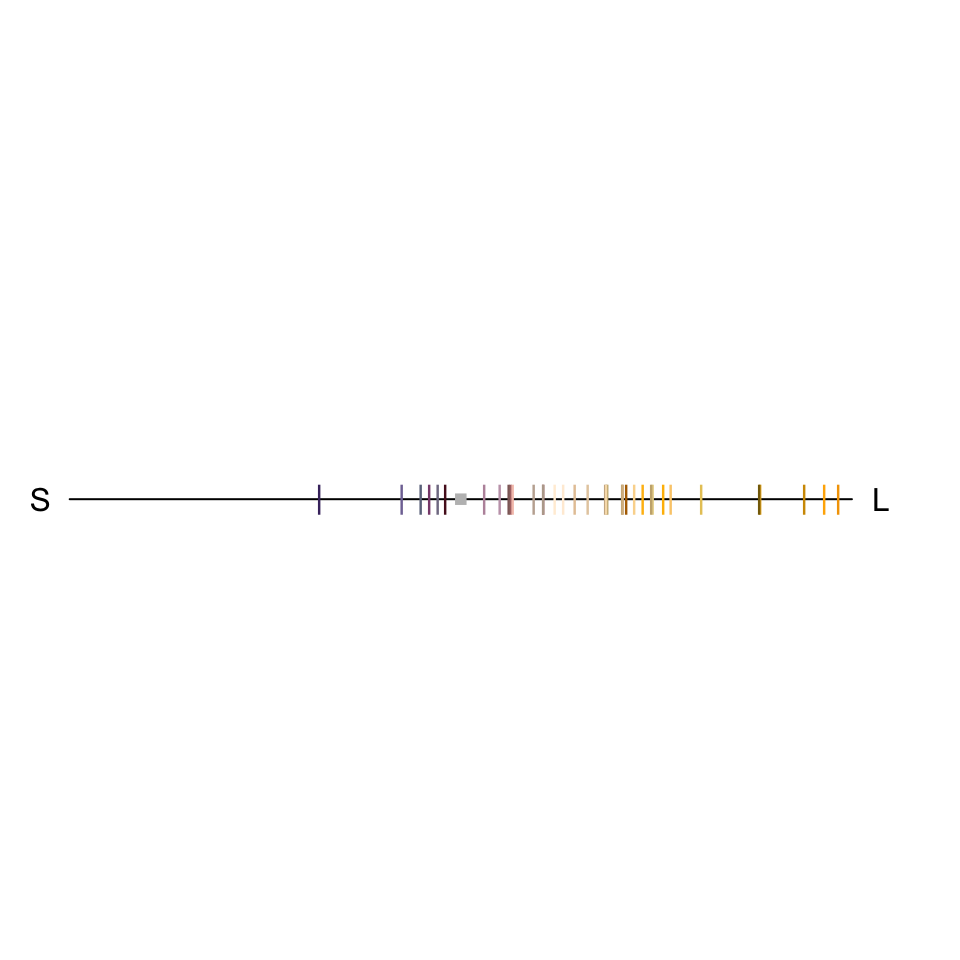

*Flowers in a dichromatic colorspace, as modelled according to a canid visual system.*

```r
plot(di.flowers, col = flowercols)
```

For our trichromatic viewer we can use the honeybee *Apis melifera*, one of the most significant and widespread pollinators. We’ll also transform our quantum catches according to Fechner’s law by specifying `qcatch = 'fi'`, and will model photoreceptor stimulation under bright conditions by scaling our illuminant with the `scale` argument.

```r
vis.flowers <- vismodel(flowers, visual = 'apis', qcatch = 'fi', scale = 10000)

tri.flowers <- colspace(vis.flowers, space = 'tri')

head(tri.flowers)
```

```
##                               s         m         l            x
## Goodenia_heterophylla 0.2680609 0.3692102 0.3627289 -0.004583018
## Goodenia_geniculata   0.2271455 0.3674126 0.4054419  0.026890830
## Goodenia_gracilis     0.1123462 0.3278566 0.5597972  0.164006728
## Xyris_operculata      0.1255093 0.4303017 0.4441890  0.009819783
## Eucalyptus_sp         0.2516894 0.3676007 0.3807098  0.009269542
## Faradaya_splendida    0.2538901 0.3503816 0.3957283  0.032064975
##                                 y   h.theta      r.vec
## Goodenia_heterophylla -0.07994212 -1.628063 0.08007338
## Goodenia_geniculata   -0.13005300 -1.366901 0.13280399
## Goodenia_gracilis     -0.27065282 -1.026001 0.31646668
## Xyris_operculata      -0.25453138 -1.532236 0.25472073
## Eucalyptus_sp         -0.09999295 -1.478359 0.10042168
## Faradaya_splendida    -0.09729766 -1.252450 0.10244509
```

As in the case of our dichromat, the output contains relative photoreceptor stimulations, coordinates in the Maxwell triangle, a well as the ‘hue angle’ `h.theta` and distance from the origin (`r.vec`).

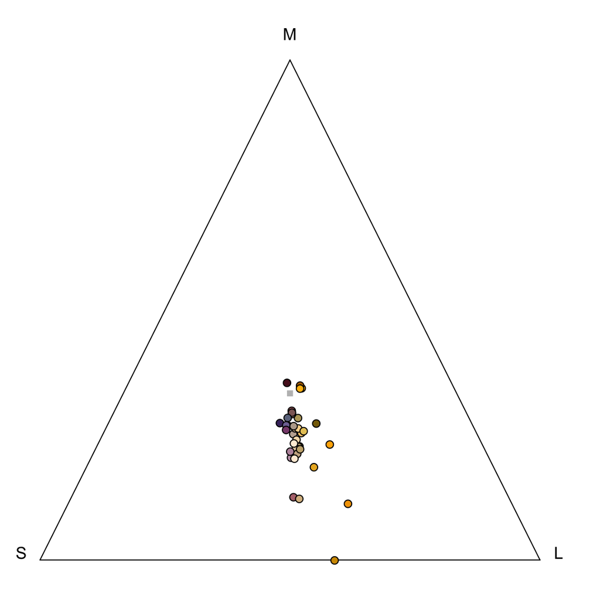

*Floral reflectance in a Maxwell triangle, considering a honeybee visual system.*

```r
plot(tri.flowers, pch = 21, bg = flowercols)
```

Finally, we’ll draw on the blue tit’s visual system to model our floral reflectance spectra in a tetrahedral space, again using log-transformed quantum catches and assuming bright viewing conditions.

```r
vis.flowers <- vismodel(flowers, visual = 'bluetit', qcatch = 'fi', scale = 10000)

tetra.flowers <- colspace(vis.flowers, space = 'tcs')

head(tetra.flowers)
```

```
##                                u         s         m         l         u.r
## Goodenia_heterophylla 0.22743747 0.2659589 0.2524136 0.2541900 -0.02256253
## Goodenia_geniculata   0.16252473 0.2721544 0.2827981 0.2825228 -0.08747527
## Goodenia_gracilis     0.04286461 0.2442994 0.3504364 0.3623997 -0.20713539
## Xyris_operculata      0.17663054 0.2709700 0.2642600 0.2881394 -0.07336946
## Eucalyptus_sp         0.21185426 0.2609393 0.2636990 0.2635074 -0.03814574
## Faradaya_splendida    0.18442467 0.2557585 0.2786359 0.2811809 -0.06557533
##                                s.r         m.r         l.r            x
## Goodenia_heterophylla  0.015958946 0.002413584 0.004189995 -0.007206981
## Goodenia_geniculata    0.022154388 0.032798126 0.032522752  0.006349301
## Goodenia_gracilis     -0.005700643 0.100436369 0.112399664  0.072321372
## Xyris_operculata       0.020970028 0.014259992 0.038139435  0.010514071
## Eucalyptus_sp          0.010939334 0.013699024 0.013507382  0.001572602
## Faradaya_splendida     0.005758476 0.028635925 0.031180928  0.015568009
##                                  y           z    h.theta     h.phi
## Goodenia_heterophylla -0.005417065 -0.02256253 -2.4970419 -1.190641
## Goodenia_geniculata    0.003860489 -0.08747527  0.5462942 -1.486052
## Goodenia_gracilis      0.033295437 -0.20713539  0.4314537 -1.203832
## Xyris_operculata      -0.010815014 -0.07336946 -0.7995067 -1.368039
## Eucalyptus_sp          0.001043454 -0.03814574  0.5858214 -1.521361
## Faradaya_splendida     0.007188605 -0.06557533  0.4325862 -1.315029
##                            r.vec     r.max r.achieved
## Goodenia_heterophylla 0.02429718 0.2692205  0.0902501
## Goodenia_geniculata   0.08779031 0.2509004  0.3499011
## Goodenia_gracilis     0.22190997 0.2678320  0.8285416
## Xyris_operculata      0.07490385 0.2552283  0.2934778
## Eucalyptus_sp         0.03819240 0.2503058  0.1525830
## Faradaya_splendida    0.06778025 0.2584061  0.2623013
```

As in previous versions of `pavo`, tetrahedral data (now via `colspace(space = 'tcs')`) may be visualised in an *interactive* plot by using `tcsplot`, along with the accessory functions `tcspoints` and `tcsvol` for adding points and convex hulls, respectively. Version `1.0`, however, now also includes a *static* tetrahedral plot, based on functionality from the package `scatterplot3d`. As with other colorspace plots there are a number of associated graphical options, though the `view` option is particularly useful in this case, as it controls the orientation of the tetrahedron by specifying a viewing angle from 0 to 360 (in degrees).

Two additional new functions may help with tetrahedral colorspace plotting: * `axistetra` function can be used to draw arrows showing the direction and magnitude of distortion of x, y and z in the tetrahedral plot. * `legendtetra` allows you to add a legend to a plot.

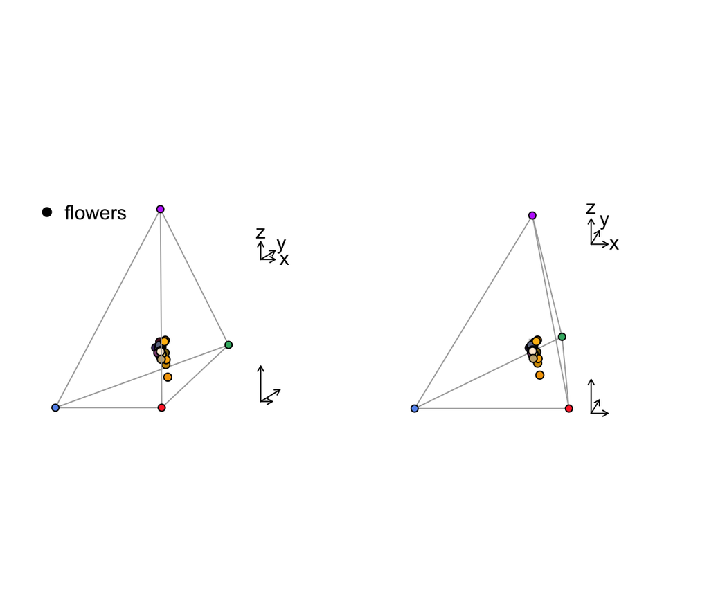

*Flowers in a tetrahedral colorspace, with varied orientations and perspectives, modelled using the visual phenotype of the blue tit. Top arrows show direction of axes, and bottom arrows of equal length shows differences in perspective and distortion.*

```r
par(mfrow = c(1, 2), pty='s')
plot(tetra.flowers, view = 30, pch = 21, bg = flowercols)
legendtetra(x=-2.6, y=0.2, z=0.8, legend='flowers', pch=19, col='black', bty='n')
axistetra(x=1.4, y=0.2, z=0.4, size=c(0.25,0.15,0.1), adj.label=c(0.06,0.08,0.07))
axistetra(x=1.4, y=0.2, z=-0.4, size=0.2, label=FALSE)
plot(tetra.flowers, view=60, scale.y=0.6, pch = 21, bg = flowercols)
axistetra(x=0.6, y=0.2, z=0.5, size=c(0.2,0.2,0.15), adj.label=c(0.07,0.12,0.07))
axistetra(x=0.6, y=0.2, z=-0.5, size=0.2, label=FALSE)
```

### The Color Hexagon

The hexagon color space of Chittka (1992) is a generalised color-opponent model of hymenopteran vision that has found extremely broad use, particularly in studies of bee-flower interactions. It’s also often broadly applied across hymenopteran species, because the photopigments underlying trichromatic vision in Hymenoptera appear to be quite conserved (Briscoe and Chittka 2001). What’s particularly useful is that color distances within the hexagon have been extensively validated against behaviour, and thus offer a relatively reliable measure of perceptual distance (Chittka 1992; e.g. Dyer et al. 2008; Avarguès-Weber et al. 2010).

In the hexagon, photoreceptor quantum catches are typically hyperbolically transformed (and `pavo` will return a warning if the transform is not selected), and vonkries correction is often used used to model photoreceptor adaptation to a vegetation background. This can all now be specified in `vismodel`. including the optional use of a ‘green’ vegetation background. Note that although this is a colorspace model, we specific `relative = FALSE` to return raw (albeit transformed) quantum catches, as required for the model (Chittka 1992).

```r
vis.flowers <- vismodel(flowers, visual = 'apis', qcatch = 'Ei', relative = FALSE, vonkries = TRUE, achro = 'l', bkg = 'green')
```

We can then apply the hexagon model in `colspace`, which will convert our photoreceptor ‘excitation values’ to coordinates in the hexagon according to:

$$x = \frac{\sqrt{3}}{2(E_g = E_{uv})}$$

$$y = E_b - 0.5(E_{uv} + E_g)$$

```r
hex.flowers <- colspace(vis.flowers, space = 'hexagon')

head(hex.flowers)
```

```
##                                 s          m         l         x
## Goodenia_heterophylla 0.086435155 0.37464448 0.2383065 0.1315245
## Goodenia_geniculata   0.040686930 0.38653516 0.4575212 0.3609891
## Goodenia_gracilis     0.001709545 0.02738349 0.3148769 0.2712109
## Xyris_operculata      0.002844880 0.26835909 0.2170078 0.1854705
## Eucalyptus_sp         0.074047589 0.42777802 0.3725662 0.2585247
## Faradaya_splendida    0.074604645 0.32783502 0.4358825 0.3128758
##                                 y   h.theta     r.vec sec.fine sec.coarse
## Goodenia_heterophylla  0.21227364  31.78230 0.2497174       30  bluegreen
## Goodenia_geniculata    0.13743110  69.15781 0.3862647       60  bluegreen
## Goodenia_gracilis     -0.13090974 115.76596 0.3011523      110      green
## Xyris_operculata       0.15843274  49.49537 0.2439267       40  bluegreen
## Eucalyptus_sp          0.20447114  51.65899 0.3296111       50  bluegreen
## Faradaya_splendida     0.07259145  76.93771 0.3211865       70  bluegreen
```

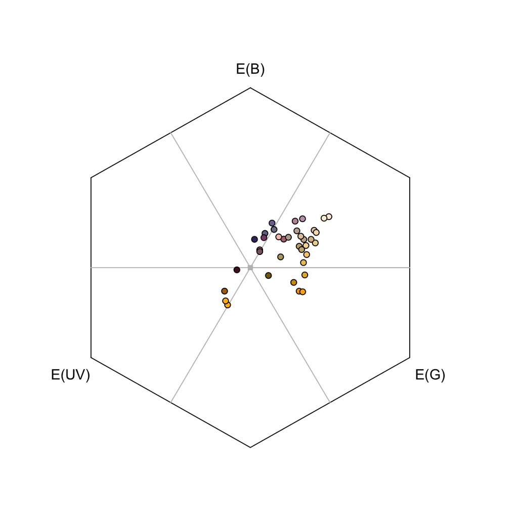

*Flowers as modelled in the hymenopteran color hexagon of Chittka (1992), overlain with coarse bee-hue sectors.*

```r
plot(hex.flowers, sectors = 'coarse', pch = 21, bg = flowercols)
```

### The Color Opponent Coding (COC) Space

The color opponent coding (coc) space is an earlier hymenopteran visual model (Backhaus 1991) which is seldom used in favour of the hexagon, though may prove useful for comparative work. While the initial estimation of photoreceptor excitation is similar to that in the hexagon, the coc subsequently specifies `A` and `B` coordinates based on empirically-derived weights for the output from each photoreceptor:

$$A = -9.86E_g + 7.70E_b + 2.16E_g$$
$$B = -5.17E_g + 20.25E_b - 15.08E_g$$

Where E<sub>i</sub> is the excitation value (quantum catch) in photoreceptor *i*.

```r
vis.flowers <- vismodel(flowers, visual = 'apis', qcatch = 'Ei', relative = FALSE, vonkries = TRUE, bkg = 'green')

coc.flowers <- colspace(vis.flowers, space = 'coc')

head(coc.flowers)
```

```
##                                 s          m         l         x
## Goodenia_heterophylla 0.086435155 0.37464448 0.2383065 2.5472539
## Goodenia_geniculata   0.040686930 0.38653516 0.4575212 3.5633933
## Goodenia_gracilis     0.001709545 0.02738349 0.3148769 0.8741309
## Xyris_operculata      0.002844880 0.26835909 0.2170078 2.5070514
## Eucalyptus_sp         0.074047589 0.42777802 0.3725662 3.3685245
## Faradaya_splendida    0.074604645 0.32783502 0.4358825 2.7302341
##                                y    r.vec
## Goodenia_heterophylla  3.5460185 6.093272
## Goodenia_geniculata    0.7175661 4.280959
## Goodenia_gracilis     -4.2026664 5.076797
## Xyris_operculata       2.1470857 4.654137
## Eucalyptus_sp          2.6613811 6.029906
## Faradaya_splendida    -0.3201549 3.050389
```

The A and B coordinates are designated x and y in the output of coc for consistency, and while the model includes a measure of saturation in `r.vec`, it contains no associated measure of hue.

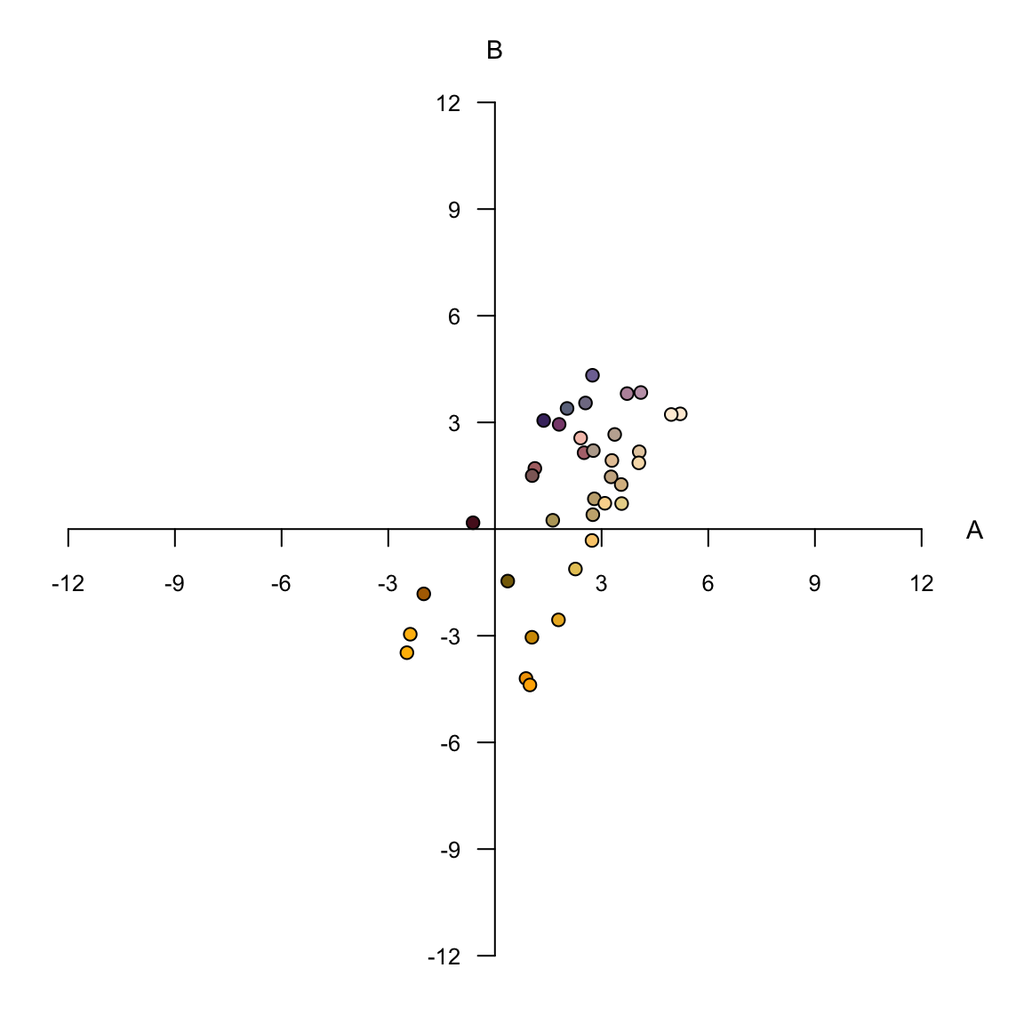

*Flowers in the color-opponent-coding space of Backhaus (1991), as modelling according to the honeybee.*

```r
plot(coc.flowers, pch = 21, bg = flowercols, yaxt='n')
```

### CIE Spaces

The CIE (International Commission on Illumination) colorspaces are a suite of models of human color vision and perception. `pavo 1.0` now includes two of the most commonly used: the foundational 1931 CIE XYZ space, and the more modern, perceptually calibrated CIE LAB space. Tristimulus values in XYZ space are calculated as:

$$X = k\int_{300}^{700}{R(\lambda)I(\lambda)\bar{x}(\lambda)d\lambda}$$
$$Y = k\int_{300}^{700}{R(\lambda)I(\lambda)\bar{y}(\lambda)d\lambda}$$
$$Z = k\int_{300}^{700}{R(\lambda)I(\lambda)\bar{z}(\lambda)d\lambda}$$

where *x*, *y*, and *z* are the trichromatic color matching functions for a ‘standard colorimetric viewer’. These functions are designed to describe an average human’s chromatic response within a specified viewing arc in the fovea (to account for the uneven distribution of cones across eye). `pavo` includes both the CIE 2-degree and the modern 10-degree standard observer, which can be selected in the `visual` option in the `vismodel` function. In these equations, k is the normalising factor

$$k = \frac{100}{\int_{300}^{700}{I(\lambda)\bar{y}(\lambda)d\lambda}}$$

and the chromaticity coordinates of stimuli are calculated as

$$x = \frac{X}{X + Y + Z}$$
$$y = \frac{Y}{X + Y + Z}$$
$$z = \frac{Z}{X + Y + Z} = 1 - x - y$$

For modelling in both XYZ and LAB spaces, here we’ll use the CIE 10-degree standard observer, and assume a `D65` ‘standard daylight’ illuminant. Again, although they are colorspace models, we need to set `relative = FALSE` to return raw quantum catch estimates, `vonkries = TRUE` to include for the required normalising factor (as above), and `achromatic = 'none'` since there is no applicable way to estimate luminance in the CIE models. As with all models that have particular requirements, `vismodel` will output warnings and/or errors if unusual or non-standard arguments are specified.

```r
vis.flowers <- vismodel(flowers, visual = 'cie10', illum = 'D65', vonkries = TRUE, relative = FALSE, achromatic = 'none')
```

```r
ciexyz.flowers <- colspace(vis.flowers, space = 'ciexyz')
head(ciexyz.flowers)
```

```
##                               X         Y         Z         x         y
## Goodenia_heterophylla 0.2074305 0.2067084 0.3013614 0.2899097 0.2889005
## Goodenia_geniculata   0.6472803 0.6752456 0.4240380 0.3706021 0.3866137
## Goodenia_gracilis     0.5153064 0.4587957 0.0153714 0.5207885 0.4636766
## Xyris_operculata      0.2884446 0.2353124 0.2224271 0.3865595 0.3153544
## Eucalyptus_sp         0.4431842 0.4470468 0.4019893 0.3429634 0.3459524
## Faradaya_splendida    0.6636975 0.6553481 0.2869075 0.4132733 0.4080743
##                                z
## Goodenia_heterophylla 0.42118974
## Goodenia_geniculata   0.24278414
## Goodenia_gracilis     0.01553492
## Xyris_operculata      0.29808613
## Eucalyptus_sp         0.31108420
## Faradaya_splendida    0.17865248
```

The output is simply the tristimulus values and chromaticity coordinates of stimuli, and we can visualise our results (along with a line connecting monochromatic loci, by default) by calling

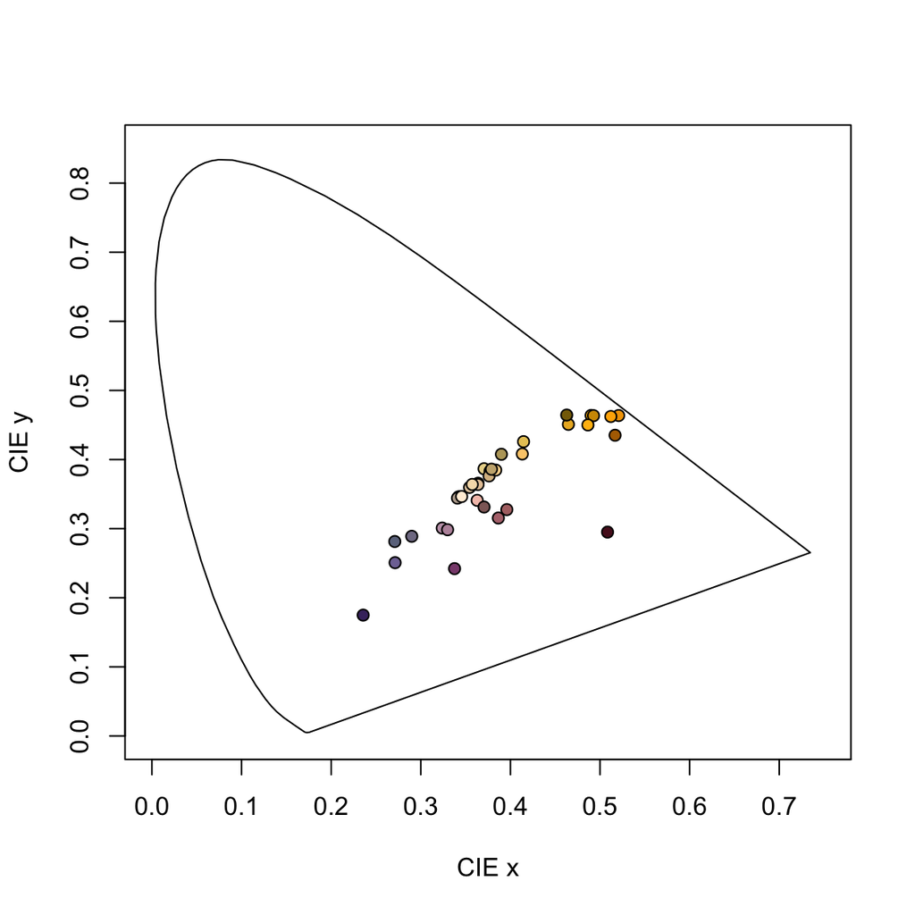

*Floral reflectance in the CIEXYZ human visual model. Note that this space is not perceptually calibrated, so we cannot make inferences about the similarity or differences of colors based on their relative location.*

```r
plot(ciexyz.flowers, pch = 21, bg = flowercols)
```

The `Lab` space is a more recent development, and is a color-opponent model that attempts to model the nonlinear responses of the human eye. The `Lab` model is also calibrated (unlike the `XYZ` model) such that Euclidean distances between points represent relative perceptual distances. This means that two stimuli that are farther apart in `Lab` space should be *percieved* as more different that two closer points. As the name suggests, the dimensions of the `Lab` space are *L*ightness (i.e. subjective brightness), along with two color-opponent dimensions designated *a* and *b*. The `colspace` function, when `space = cielab`, simply converts points from the `XYZ` model according to:

$$L = 116\left(\frac{Y}{Y_n}\right)^\frac{1}{3} \;\; if \;\; \frac{Y}{Y_n} > 0.008856$$
$$L = 903.3\left(\frac{Y}{Y_n}\right) \;\; if \;\; \frac{Y}{Y_n} \leq 0.008856$$

$$a = 500\left(f\left(\frac{X}{X_n}\right) - f\left(\frac{Y}{Y_n}\right)\right)$$

$$b = 500\left(f\left(\frac{Y}{Y_n}\right) - f\left(\frac{Z}{Z_n}\right)\right)$$

where

$$f(x) = x^\frac{1}{3} \;\; if \;\; x > 0.008856$$
$$f(x) = 7.787(x) + \frac{16}{116} \;\; if \;\; x \leq 0.008856$$

Here, $X_n, Y_n, Z_n$ are neutral point values to model visual adaptation, calculated as:

$$X_n = \int_{300}^{700}{R_n(\lambda)I(\lambda)\bar{x}(\lambda)d\lambda}$$
$$Y_n = \int_{300}^{700}{R_n(\lambda)I(\lambda)\bar{y}(\lambda)d\lambda}$$
$$Z_n = \int_{300}^{700}{R_n(\lambda)I(\lambda)\bar{z}(\lambda)d\lambda}$$

when $R_n(\lambda)$ is a perfect diffuse reflector (i.e. 1).

```r
cielab.flowers <- colspace(vis.flowers, space = 'cielab')
head(cielab.flowers)
```

```
##                               X         Y         Z        L            a
## Goodenia_heterophylla 0.2074305 0.2067084 0.3013614 1.691253  0.091908831
## Goodenia_geniculata   0.6472803 0.6752456 0.4240380 5.524744 -0.778898966
## Goodenia_gracilis     0.5153064 0.4587957 0.0153714 3.753788  2.157990123
## Xyris_operculata      0.2884446 0.2353124 0.2224271 1.925286  1.966170677
## Eucalyptus_sp         0.4431842 0.4470468 0.4019893 3.657660  0.005744138
## Faradaya_splendida    0.6636975 0.6553481 0.2869075 5.361946  0.507048199
##                                b
## Goodenia_heterophylla -2.4336189
## Goodenia_geniculata    1.9981497
## Goodenia_gracilis      6.1991586
## Xyris_operculata      -0.6289287
## Eucalyptus_sp         -0.8295538
## Faradaya_splendida     4.1517115
```

Our output now contains the tristimulus `XYZ` values, as well as their `Lab` counterparts, which are coordinates in the `Lab` space. These can also be visualised in three-dimensional `Lab` space by calling `plot`:

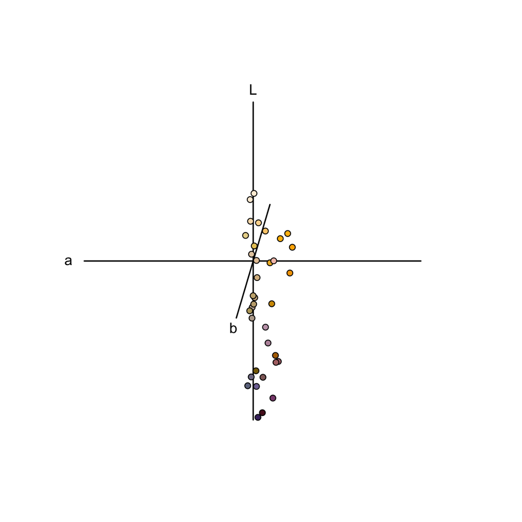

*CIELAB.*

```r
plot(cielab.flowers, pch = 21, bg = flowercols)
```

### Categorical Fly colorspace

The categorical color vision model of Troje (1993) is a model of dipteran vision, based on behavioural data from the blowfly *Lucilia* sp. It assumes the involvement of all four dipteran photoreceptor classes (R7 & R8 ‘pale’ and ‘yellow’ subtypes), and further posits that color vision is based on two specific opponent mechanisms (R7p - R8p, and R7y - R8y). The model assumes that all colors are perceptually grouped into one of four color categories, and that flies are unable to distinguish between colors that fall within the same category.

We’ll use the visual systems of the mudcoid fly *Musca domestica*, and will begin by estimating linear (i.e. untransformed) quantum catches for each of the four photoreceptors (Troje 1993).

```r
vis.flowers <- vismodel(flowers, qcatch = 'Qi', visual = 'musca', achro = 'none', relative = TRUE)
```

Our call to `colspace` will then simply estimate the location of stimuli in the categorical space as the difference in relative stimulation between ‘pale’ (R7p - R8p) and ‘yellow’ (R7y - R8y) photoreceptor pairs:

$$x = R7_p - R8_p$$

$$y = R7_y - R8_y$$

```r
cat.flowers <- colspace(vis.flowers, space = 'categorical')

head(cat.flowers)
```

```
##                               R7p        R7y       R8p       R8y
## Goodenia_heterophylla 0.036748525 0.18750232 0.4831894 0.2925597
## Goodenia_geniculata   0.014425754 0.08432394 0.4234800 0.4777703
## Goodenia_gracilis     0.008460324 0.02696304 0.1702152 0.7943614
## Xyris_operculata      0.008614719 0.12477105 0.4972701 0.3693441
## Eucalyptus_sp         0.023808699 0.14355472 0.4468683 0.3857682
## Faradaya_splendida    0.025364796 0.09511658 0.3602082 0.5193104
##                                x          y category     r.vec
## Goodenia_heterophylla -0.4464409 -0.1050574     p-y- 0.4586355
## Goodenia_geniculata   -0.4090543 -0.3934464     p-y- 0.5675609
## Goodenia_gracilis     -0.1617549 -0.7673984     p-y- 0.7842608
## Xyris_operculata      -0.4886554 -0.2445731     p-y- 0.5464431
## Eucalyptus_sp         -0.4230596 -0.2422135     p-y- 0.4874904
## Faradaya_splendida    -0.3348434 -0.4241939     p-y- 0.5404262
```

And it is simply the signs of these differences that define the four possible fly-color categories (p+y+, p-y+, p+y-, p-y-), which we can see in the associated plot.

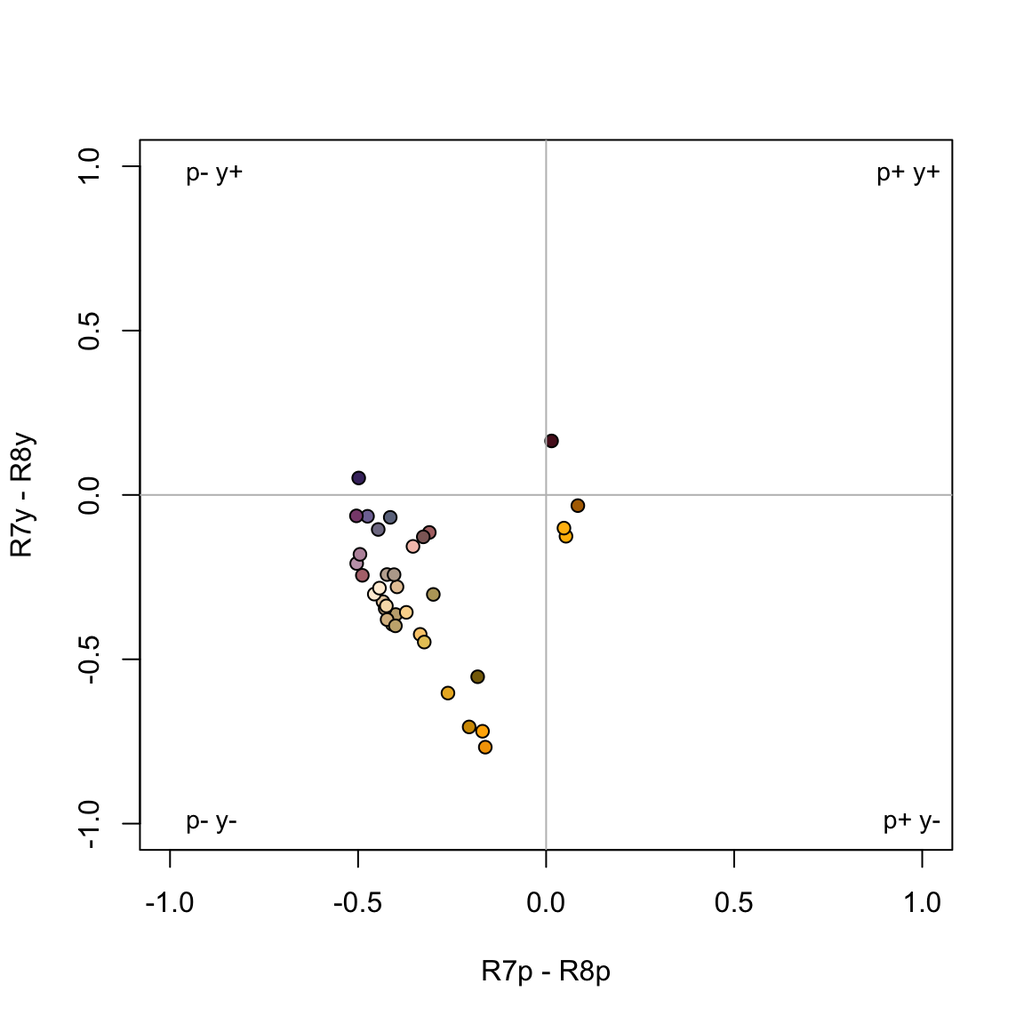

*Flowers in the categorical colorspace of Troje (1993).*

```r
plot(cat.flowers, pch = 21, bg = flowercols)
```

# Changes to `coldist`

## Argument Changes to `coldist`

The most important change to `coldist` is that some of its arguments have changed, with implications for receptor-noise modelling. In `pavo 1.0`, `coldist` requires the empirically estimated value for the Weber fraction to be entered, instead of the single cone noise-to-signal ratio (the `v` argument in previous versions of `pavo`). Further, instead of separately entering `n1, n2, n3` and `n4`, `coldist` now has a single argument `n`, and a vector of relative cone abundances is the required input. Finally, the argument `weber.ref` specifies which cone to use as the reference cone for the desired Weber fraction.

The noise-to-signal ratio is then calculated based on the empirically estimated Weber fraction for the reference cone type (which must also be specified), and applied to the remaining cone types. This is largely to avoid confusion between empirically estimated values for the Weber fraction and the noise-to-signal ratio, which are common in the literature. It was also made to demand less of the user, who used to have to calculate what value of `v` to use given the desired Weber fraction and relative cone abundances.

So, for example, the code below used in previous versions of `pavo`:

```r
data(sicalis)
vis.sicalis <- vismodel(sicalis, relative = FALSE)
JND.sicalis <- coldist(vis.sicalis, n1 = 1, n2 = 2, n3 = 2, n4 = 4, v = 0.2)
```

in `pavo 1.0` would be:

```r
data(sicalis)
vis.sicalis <- vismodel(sicalis, relative = FALSE)
JND.sicalis <- coldist(vis.sicalis, n = c(1, 2, 2, 4), weber = 0.1, weber.ref = 4)
head(JND.sicalis)
```

```
##   patch1 patch2         dS       dL
## 1 ind1.C ind1.T  3.5206558 6.653493
## 2 ind1.C ind1.B  1.4452940 7.980093
## 3 ind1.C ind2.C  0.6797948 3.389606
## 4 ind1.C ind2.T 10.5195704 7.199048
## 5 ind1.C ind2.B  2.7180185 6.341610
## 6 ind1.C ind3.C  3.2067444 4.542846
```

or alternatively, `weber.ref` can be simply set to “longest”:

```r
data(sicalis)
vis.sicalis <- vismodel(sicalis, relative = FALSE)
JND.sicalis <- coldist(vis.sicalis, n = c(1, 2, 2, 4), weber = 0.1, weber.ref = 'longest')
head(JND.sicalis)
```

```
##   patch1 patch2         dS       dL
## 1 ind1.C ind1.T  3.5206558 6.653493
## 2 ind1.C ind1.B  1.4452940 7.980093
## 3 ind1.C ind2.C  0.6797948 3.389606
## 4 ind1.C ind2.T 10.5195704 7.199048
## 5 ind1.C ind2.B  2.7180185 6.341610
## 6 ind1.C ind3.C  3.2067444 4.542846
```

`coldist` now also accepts a `weber.achro` argument so that the value for the Weber fraction to be used to calculate achromatic contrast can be input independently of the cone ratios.

## Color Distances in *N*-Dimensions

As a result of the changes in the input of relative cone abundances and the internal calculation functions used in `coldist`, the function is not limited to di-, tri- or tetrachromatic visual systems. `coldist` has been generalised, and can now calculate color distances for n-dimensional visual phenotypes. This means there is no limit on the dimensionality of visual systems that may be input, which may prove useful for modelling nature’s extremes (e.g. butterflies, mantis shrimp) or for simulation-based work. Naturally, since these calculations aren’t largely implemented elsewhere, we recommend caution and validation of results prior to publication.

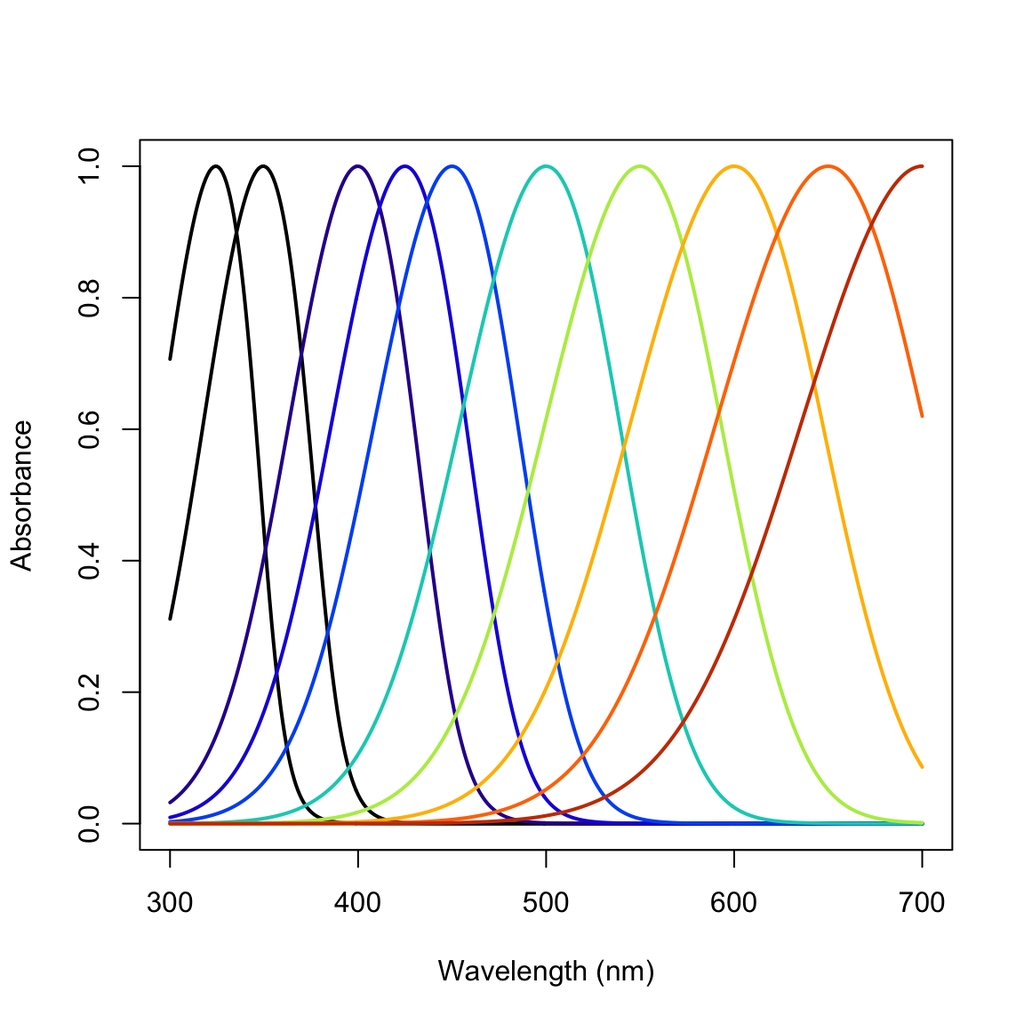

*Visual system of a pretend mantis shrimp with 10 cones*

```r
# Create an arbitrary visual phenotype with 10 photoreceptors
fakemantisshrimp <- sensmodel(c(325, 350, 400, 425, 450, 500, 550, 600, 650, 700), beta = FALSE, integrate = FALSE)

# Convert to percentages, just to color the plot
fakemantisshrimp.colors <- fakemantisshrimp * 100
fakemantisshrimp.colors[, 'wl'] <- fakemantisshrimp[, 'wl']

plot(fakemantisshrimp, col = spec2rgb(fakemantisshrimp.colors), lwd = 2, ylab = 'Absorbance')
```

```r
# Run visual model and calculate color distances
vm.fms <- vismodel(flowers, visual = fakemantisshrimp, relative = FALSE, achro = FALSE)

JND.fms <- coldist(vm.fms, n = c(1, 1, 2, 2, 3, 3, 4, 4, 5, 5))
head(JND.fms)
```

```
##                  patch1              patch2        dS
## 1 Goodenia_heterophylla Goodenia_geniculata 16.297557
## 2 Goodenia_heterophylla   Goodenia_gracilis 48.390309
## 3 Goodenia_heterophylla    Xyris_operculata 30.760482
## 4 Goodenia_heterophylla       Eucalyptus_sp  6.044184
## 5 Goodenia_heterophylla  Faradaya_splendida 15.901435
## 6 Goodenia_heterophylla  Gaultheria_hispida 11.188246
```

# Classes and Attributes

To enable the improved workflow and new features in `pavo 1.0`, we’ve expanded the underlying class system. As in previous versions, spectra will be of class `rspec` as long as we use one of `pavo`’s spectral import or processing funcitons, or explicitly convert an object using `as.rspec`. The results of `vismodel` are now objects of class `vismodel` and the results of `colspace` are, unsurprisingly, objects of class `colspace`. Both of these classes inherit from `data.frame`, and contain a suite of attributes that describe the object’s characteristics (e.g. options used in visual modelling such as the selected visual system and illuminant, and properties of the modelled colorspace). These are easily viewed using the `summary` function (on any `rspec`, `vismodel`, or `colspace` object), which will return the attributes and summary data (where appropriate) in a readable format.

# Concluding Thoughts, and Further Assistance

We hope that we have piqued your interest in `pavo 1.0` by illustrating some of its exciting new features. Although many of the changes are significant (and breaking), we feel the package is in its most useful form yet, which will also act as a solid foundation for expansion in the future. As always, we appreciate your interest in `pavo`, and are happy to hear from you.

For suggestions, assistance and/or bug reports, we suggest getting in touch via ‘gitter’ at https://gitter.im/r-pavo/help, which is essentially a public chat room for all things pavo. If you have a bug to report, we’d appreciate it if you could also include a reproducible example when possible. Users familiar with git may prefer to open an issue on the project’s [github page](https://github.com/rmaia/pavo), or to make a pull-request directly.

# References

Avarguès-Weber, A., M. G. de Brito Sanchez, M. Giurfa, and A. G. Dyer. 2010. Aversive reinforcement improves visual discrimination learning in free-flying honeybees. PLoS One 5:e15370.

Backhaus, W. 1991. Color opponent coding in the visual system of the honeybee. Vision research 31:1381–1397.

Backhaus, W., and R. Menzel. 1987. Color distance derived from a receptor model of color vision in the honeybee. Biological Cybernetics 55:321–331.

Briscoe, A. D., and L. Chittka. 2001. The evolution of color vision in insects. Annual review of entomology 46:471–510.

Chittka, L. 1992. The colour hexagon: A chromaticity diagram based on photoreceptor excitations as a generalized representation of colour opponency. Journal of Comparative Physiology A 170:533–543.

Chittka, L., A. Shmida, N. Troje, and R. Menzel. 1994. Ultraviolet as a component of flower reflections, and the colour perception of hymenoptera. Vision research 34:1489–1508.

Dowling, J. E. 1987. The retina: An approachable part of the brain. Harvard University Press.

Dyer, A. G., S. Boyd-Gerny, S. McLoughlin, M. G. P. Rosa, V. Simonov, and B. B. M. Wong. 2012. Parallel evolution of angiosperm colour signals: Common evolutionary pressures linked to hymenopteran vision. Proceedings of the Royal Society B-Biological Sciences 279:3606–3615.

Dyer, A. G., J. Spaethe, and S. Prack. 2008. Comparative psychophysics of bumblebee and honeybee colour discrimination and object detection. Journal of Comparative Physiology A 194:617–627.

Troje, N. 1993. Spectral categories in the learning behaviour of blowflies. Zeitschrift fur Naturforschung C 48:96–96.